# Non-pledge recording adjustment

2025-05-12

```r
pacman::p_load(tidyverse, dbplyr, gt)
```

```r
# Establish read connect to parfit
source("connect-parfit.R")
```

```
## Using stored credentials for authentication.
```

# Document purpose

Here I aim to estimate a recording adjustment for non-pledge donations for the 2023–2024 period.

# Background

Prior to our spinout from Effective Ventures in 2024, GWWC’s normal systems for tracking donations did not capture all payment types. In particular, we had little oversight of:

- Stock donations
- Payroll giving
- DAF donations

In order to account for donations of these types that occurred prior to spinout and that we therefore have no records of I will estimate what fraction of post-spinout donations these constitute and estimate a recording coefficient for all 2023–2024 donations based on this.

# Method and results

To estimate the proportion of total non-pledge donations in 2023 and 2024 that went unrecorded, we will estimate the proportion of total recorded donations of the type we have poor oversight of both prior to spinout and after spinout. We will then assume that the fraction of these donations that occurred prior to spinout was the same that occurred after spinout and use this to estimate actual non-pledge donations through the GWWC platform during 2023–2024.

## Step 1: Filtering donations

First we want to create a query that will get all the donations we want to include in our estimate of non-pledge donations. This means filtering to:

```r
# Get non-pledge donation ids
non_pledge <- tbl(con, in_schema("reporting", "complete_giving_report")) %>%
  filter(is.na(pledge_id)) %>%
  select(payment_id) %>%
  distinct()

# Filter just for eligible payments
eligible_payments <- tbl(con, in_schema("payments","payment")) %>%
    mutate(
      year_month = to_char(donation_date, 'YYYY-MM'),
      donation_year = year(donation_date)
    )  %>%
  # Join inflation rate
  left_join(
    tbl(con, in_schema("impact_surveys","inflation_data")),
    by = join_by(donation_year == year)
  ) %>%
  # Adjust for inflation and exchange rate
  mutate(
    amount_adj_usd = amount_normalized * cumulative_inflation_to_2024,
    # Categorise donations as either pre or post-spinout
    post_spinout = recipient %in% c("gwwc-uk", "gwwc-us")
    ) %>%
  filter(
    status == "succeeded", # Include successful payments
    donation_year %in% 2023:2024, # Filter to include donations in period
    sum(amount_adj_usd, na.rm = TRUE) <= 139e3, # Exclude where total donations exceed 140K...
    .by = c(person_id, donation_year) # For a given person-year
  ) %>%
  # Filter for non-pledge donations
  semi_join(non_pledge, join_by(id == payment_id))
```

To see which entities handled donations made through the GWWC platform at different times, we can plot this. Since spinout, donations are mostly handled by GWWC UK and GWWC US.

```r
by_date_entity <- eligible_payments %>%
  summarise(
    num_payments = n(),
    recorded_amount = sum(amount_adj_usd),
    .by = c(recipient,year_month)
  ) %>%
  collect()
```

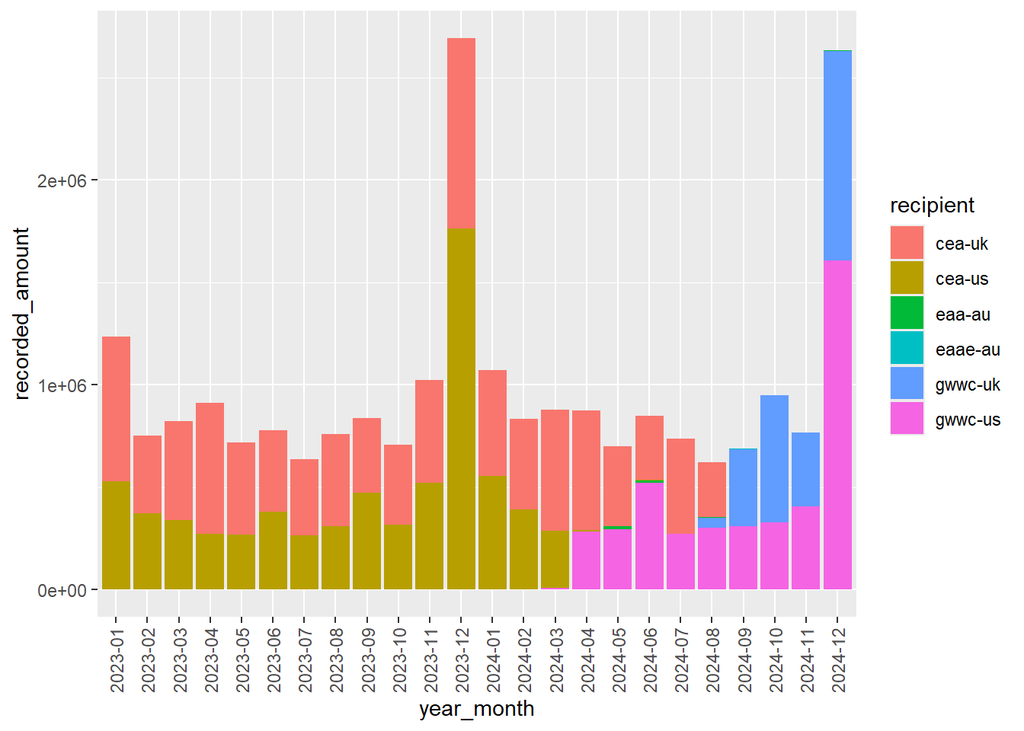

```r
by_date_entity %>%
  ggplot(aes(x = year_month, y = recorded_amount, fill = recipient)) +
  geom_col() +
  theme(axis.text.x = element_text(angle = 90, vjust = 0.5))
```

## Step 2: Estimate total reconciled donations by payment method and whether it occurred pre or post-spinout

The below table summarises the reconciled donations GWWC processed in 2023 and 2024, based on whether they occurred prior to or after spinout and whether they were a type of donation typically recorded in our systems prior to spinout (Other payment types) or not.

```r
reconciled_donations <- eligible_payments %>%
  mutate(payment_oversight = if_else(
    payment_method %in% c("payroll giving", "donor advised fund", "stock", "cheque"),
    as.character(payment_method),
    "Other payment types"
    )) %>%
  summarise(
    total_period = sum(amount_adj_usd),
    .by = c(post_spinout,payment_oversight)
  ) %>%
  collect()

reconciled_donations %>%
  gt(caption = "Reconciled non-pledge donations by payment type and whether they occurred before or after spinout (2023–2024)") %>%
  fmt_currency(3, suffixing = T)
```

Reconciled non-pledge donations by payment type and whether they occurred before or after spinout (2023–2024)

| post_spinout | payment_oversight | total_period |
| --- | --- | --- |
| FALSE | donor advised fund | $156.57K |
| FALSE | Other payment types | $16.54M |
| FALSE | stock | $28.97K |
| TRUE | cheque | $117.65K |
| TRUE | donor advised fund | $393.54K |
| TRUE | Other payment types | $6.20M |
| TRUE | payroll giving | $51.08K |

## Step 3: Add unreconciled payments

```r
unreconciled_donations <- tribble(
  ~payment_oversight, ~amount, ~currency_code, ~conversion_factor,
  "payroll giving", 12e3,  "GBP", 1.29, #(From Google 31 October 2024)
  "payroll giving", 120e3, "USD", 1,
  "stocks",         101e3, "USD", 1
  ) %>%
  summarise(
    total_period = sum(amount * conversion_factor),
    post_spinout = T,
    .by = payment_oversight
  )
```

Let’s get a look at our total donations for 2023–2024 by whether they are a payment type GWWC typically has oversight of and whether they were made pre or post spinout:

```r
all_donations <- bind_rows(
  unreconciled_donations,
  reconciled_donations
) %>%
  mutate(prespinout_oversight = payment_oversight == "Other payment types") %>%
  summarise(
    total_period = sum(total_period),
    .by = c(post_spinout, prespinout_oversight)
  )

all_donations %>%
  arrange(post_spinout, prespinout_oversight) %>%
  gt(caption =  "Known non-pledge donations by payment type and whether they occurred before or after spinout (2023–2024)") %>%
  fmt_currency(3, suffixing = T)
```

Known non-pledge donations by payment type and whether they occurred before or after spinout (2023–2024)

| post_spinout | prespinout_oversight | total_period |
| --- | --- | --- |
| FALSE | FALSE | $185.54K |
| FALSE | TRUE | $16.54M |
| TRUE | FALSE | $798.76K |
| TRUE | TRUE | $6.20M |

## Step 4: Estimate missing donations

Next, we can estimate the actual total non-pledge donations, by working out what proportion of the donations post spinout would likely not have been recorded if they occurred pre-spinout and assuming these types of donations contributed the same proportion to the total, pre spinout.

```r
estimate_missing <- all_donations %>%
  summarise(
    total_in_database = sum(total_period),
    recorded_type_prespinout = sum(total_period[prespinout_oversight]),
    unrecorded_type_prespinout = sum(total_period[!prespinout_oversight]),
    percent_of_unrecorded_type = unrecorded_type_prespinout/total_in_database,
    .by = post_spinout
  ) %>%
  mutate(
    # Estimate actual donations
    actual_estimate = if_else(post_spinout,
                     total_in_database,
                     # Recorded donations prespinout over percent of recorded type post-spinout
                     recorded_type_prespinout/(1-percent_of_unrecorded_type[post_spinout])
    )
    )


estimate_missing %>%
  gt() %>%
  fmt_currency(c(2:4,6),suffixing = T) %>%
  fmt_percent(5)
```

| post_spinout | total_in_database | recorded_type_prespinout | unrecorded_type_prespinout | percent_of_unrecorded_type | actual_estimate |
| --- | --- | --- | --- | --- | --- |
| TRUE | $7.00M | $6.20M | $798.76K | 11.42% | $7.00M |
| FALSE | $16.72M | $16.54M | $185.54K | 1.11% | $18.67M |

## Step 5: Create a recording coefficient

From this we can estimate a recording coefficient by getting estimated actual donations as a proportion of recorded donations.

```r
recording_coefficient <- estimate_missing %>%
  summarise(across(c(total_in_database, actual_estimate), sum),
            coefficient = actual_estimate / total_in_database)

recording_coefficient %>%
  gt(caption = "Estimated non-pledge recording coefficient for 2023–2024") %>%
  fmt_percent(3) %>%
  fmt_currency(1:2,suffixing = T)
```

Estimated non-pledge recording coefficient for 2023–2024

| total_in_database | actual_estimate | coefficient |
| --- | --- | --- |
| $23.72M | $25.67M | 108.20% |